# Statistical Computing Final Homework

Gülderen Sungur

July 9, 2021

Abstract

Energy is a concept with a wide definition range. We use and need many types of energy in daily life. As we all know, energy sources are not endless and will run out one day. Therefore, countries take different steps on issues such as energy saving and energy production. In this report, Izmir’s electrical energy production and chemical energy consumption datasets are analyzed. According to these analyses, the energy consumption of certain tram/metro stations in Izmir differ from each other. In the Harmandalı Electricity generation dataset, the differences between the planned and produced electrical energy were examined.

# Data Visualization

## Data Description

#### DataSet 1: Energy Consumption for per passenger

```r
enerji.tuketimi.yolcubasina <- read.csv2("C:/Users/gulde/Downloads/enerji-tuketimi-yolcubasina.csv")
head(enerji.tuketimi.yolcubasina)
```

```
##    YIL AY IZMIR_METRO KARSIYAKA_TRAMVAYI KONAK_TRAMVAYI
## 1 2020  1        0.52               0.44           0.31
## 2 2020  2        0.48               0.41           0.27
## 3 2020  3        0.68               0.69           0.42
## 4 2020  4        2.03               5.94           1.77
## 5 2020  5        1.56               4.23           1.34
## 6 2020  6        0.91               1.28           0.67
```

```r
summary(enerji.tuketimi.yolcubasina)
```

```
##       YIL             AY         IZMIR_METRO     KARSIYAKA_TRAMVAYI
##  Min.   :2020   Min.   : 1.00   Min.   :0.4800   Min.   :0.410
##  1st Qu.:2020   1st Qu.: 3.75   1st Qu.:0.8225   1st Qu.:0.685
##  Median :2020   Median : 6.50   Median :0.9000   Median :1.020
##  Mean   :2020   Mean   : 6.50   Mean   :1.0000   Mean   :1.665
##  3rd Qu.:2020   3rd Qu.: 9.25   3rd Qu.:1.0725   3rd Qu.:1.677
##  Max.   :2020   Max.   :12.00   Max.   :2.0300   Max.   :5.940
##  KONAK_TRAMVAYI
##  Min.   :0.2700
##  1st Qu.:0.4350
##  Median :0.5900
##  Mean   :0.7017
##  3rd Qu.:0.7175
##  Max.   :1.7700
```

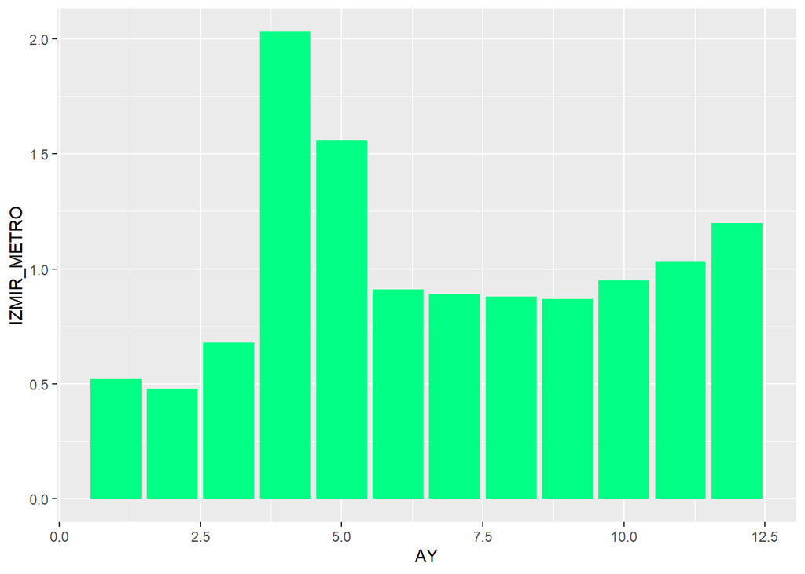

```r
ggplot2::ggplot(data = enerji.tuketimi.yolcubasina, ggplot2::aes(x = AY, y = IZMIR_METRO)) + ggplot2::geom_bar(stat="identity",fill="#00FF84")
```

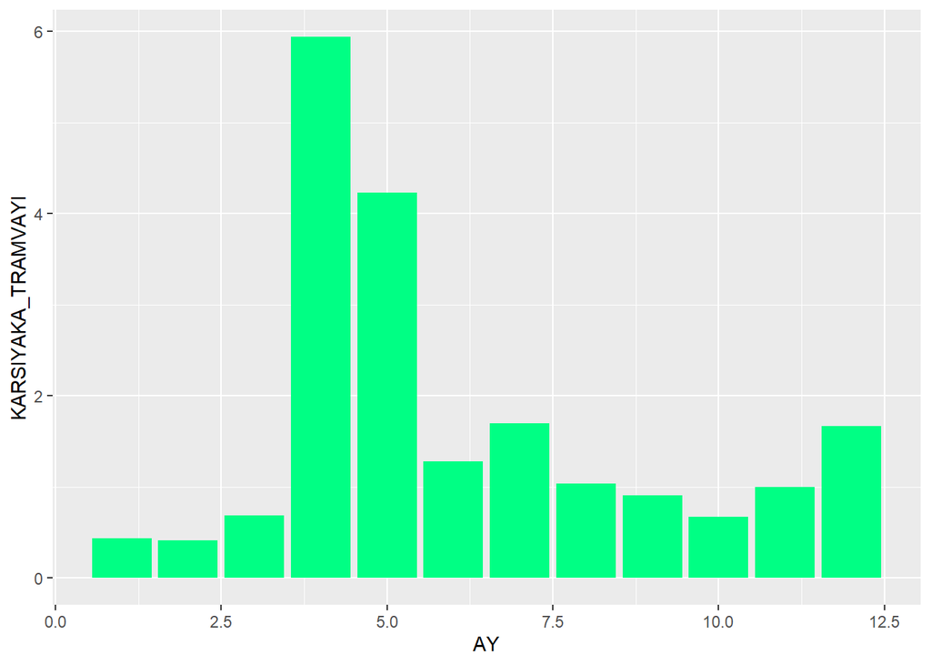

```r
ggplot2::ggplot(data = enerji.tuketimi.yolcubasina, ggplot2::aes(x = AY, y = KARSIYAKA_TRAMVAYI)) + ggplot2::geom_bar(stat="identity",fill="#00FF84")
```

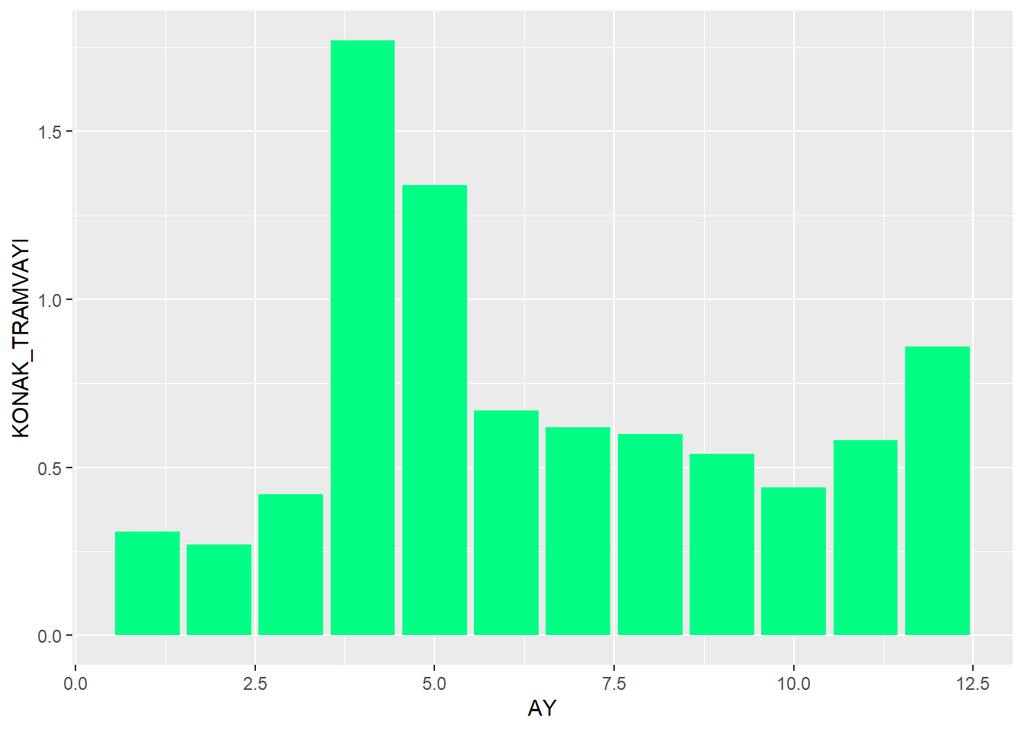

```r
ggplot2::ggplot(data = enerji.tuketimi.yolcubasina, ggplot2::aes(x = AY, y = KONAK_TRAMVAYI )) + ggplot2::geom_bar(stat="identity",fill="#00FF84")
```

As can be seen in the barcharts shown above, the energy consumed per passenger by the Karşıyaka tram is higher than the others. Karşıyaka tram is followed by İzmir Metro. Konak Tramway had the lowest energy consumption per passenger. For each area, it was observed that the highest energy consumption in the year was observed in the 4th month. The least energy consumption occurred in the 2nd month for each area.

```r
diff(enerji.tuketimi.yolcubasina$KARSIYAKA_TRAMVAYI - enerji.tuketimi.yolcubasina$KONAK_TRAMVAYI)
```

```
##  [1]  0.01  0.13  3.90 -1.28 -2.28  0.47 -0.64 -0.07 -0.14  0.19  0.39
```

```r
diff(enerji.tuketimi.yolcubasina$KARSIYAKA_TRAMVAYI - enerji.tuketimi.yolcubasina$IZMIR_METRO)
```

```
##  [1]  0.01  0.08  3.90 -1.24 -2.30  0.44 -0.65 -0.12 -0.32  0.25  0.50
```

```r
diff(enerji.tuketimi.yolcubasina$KONAK_TRAMVAYI - enerji.tuketimi.yolcubasina$IZMIR_METRO)
```

```
##  [1]  5.551115e-17 -5.000000e-02  2.775558e-16  4.000000e-02 -2.000000e-02
##  [6] -3.000000e-02 -1.000000e-02 -5.000000e-02 -1.800000e-01  6.000000e-02
## [11]  1.100000e-01
```

The table above shows the differences in energy consumption by location.

#### DataSet 2: Energy Consumption for per km

```r
enerji.tuketimi.cer <- read.csv2("C:/Users/gulde/Downloads/enerji-tuketimi-cer.csv")
head(enerji.tuketimi.cer)
```

```
##    YIL AY IZMIR_METRO KARSIYAKA_TRAMVAYI KONAK_TRAMVAYI
## 1 2020  1        1.99               4.57           3.86
## 2 2020  2        1.77               4.14           3.49
## 3 2020  3        1.93               3.77           3.44
## 4 2020  4        1.82               4.55           3.97
## 5 2020  5        1.80               5.41           3.99
## 6 2020  6        2.37               4.96           4.21
```

```r
summary(enerji.tuketimi.cer)
```

```
##       YIL             AY         IZMIR_METRO    KARSIYAKA_TRAMVAYI
##  Min.   :2020   Min.   : 1.00   Min.   :1.770   Min.   :3.540
##  1st Qu.:2020   1st Qu.: 3.75   1st Qu.:1.903   1st Qu.:4.048
##  Median :2020   Median : 6.50   Median :1.980   Median :4.700
##  Mean   :2020   Mean   : 6.50   Mean   :2.137   Mean   :4.649
##  3rd Qu.:2020   3rd Qu.: 9.25   3rd Qu.:2.415   3rd Qu.:5.232
##  Max.   :2020   Max.   :12.00   Max.   :2.650   Max.   :5.910
##  KONAK_TRAMVAYI
##  Min.   :3.250
##  1st Qu.:3.490
##  Median :3.980
##  Mean   :4.124
##  3rd Qu.:4.425
##  Max.   :5.440
```

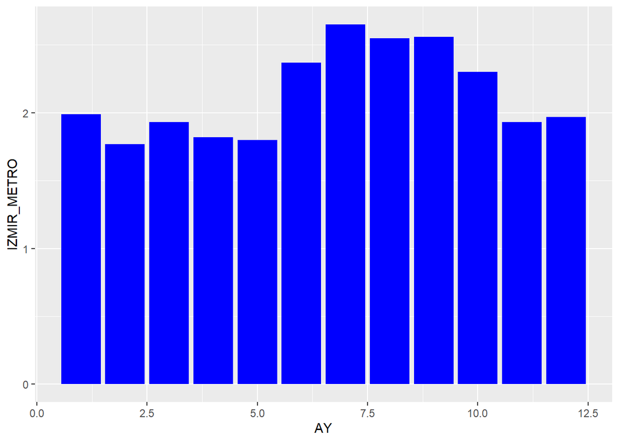

```r
ggplot2::ggplot(data = enerji.tuketimi.cer, ggplot2::aes(x = AY, y = IZMIR_METRO)) + ggplot2::geom_bar(stat="identity",fill="blue")
```

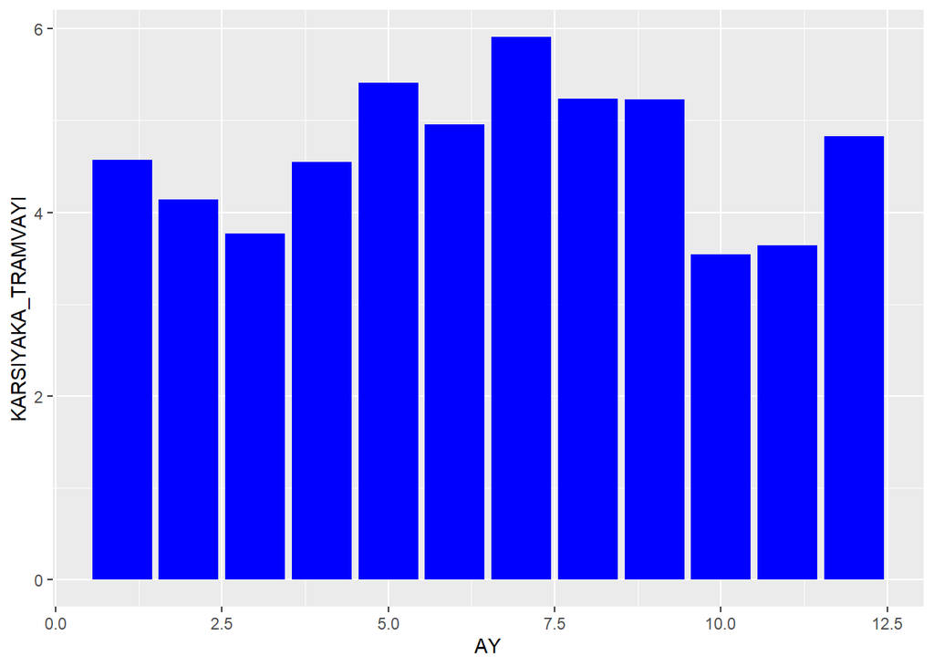

```r
ggplot2::ggplot(data = enerji.tuketimi.cer, ggplot2::aes(x = AY, y = KARSIYAKA_TRAMVAYI)) + ggplot2::geom_bar(stat="identity",fill="blue")
```

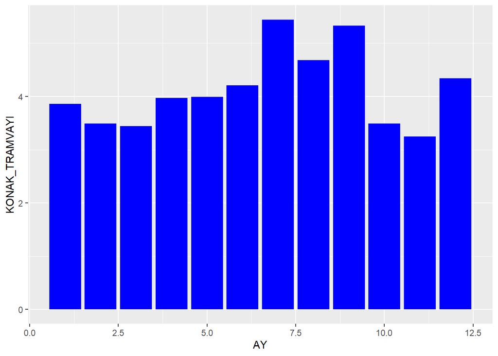

```r
ggplot2::ggplot(data = enerji.tuketimi.cer, ggplot2::aes(x = AY, y = KONAK_TRAMVAYI )) + ggplot2::geom_bar(stat="identity",fill="blue")
```

According to the graphics shown above, the station with the highest energy consumption per km is Karşıyaka Tramway. It is followed by Konak Tram. The minimum energy consumption per km is in İzmir Metro. Let’s take a look at the energy consumption differences by station to see more detailed results.

```r
diff(enerji.tuketimi.cer$KARSIYAKA_TRAMVAYI - enerji.tuketimi.cer$IZMIR_METRO)
```

```
##  [1] -0.21 -0.53  0.89  0.88 -1.02  0.67 -0.57 -0.02 -1.43  0.47  1.15
```

```r
diff(enerji.tuketimi.cer$KONAK_TRAMVAYI - enerji.tuketimi.cer$IZMIR_METRO)
```

```
##  [1] -0.15 -0.21  0.64  0.04 -0.35  0.95 -0.66  0.64 -1.58  0.13  1.05
```

#### Dataset 3: Harmandalı Electricity Production

This dataset is generated by the Izmir Municipality (IBB Acik Veri Portali https://acikveri.bizizmir.com/dataset/6331e364-8128-4f40-b836-1cc57c80adfe/resource/5a23015b-a8fa-465a-ac75-082901e7c718/download/harmandali-enerji-uretimi.csv). This dataset contains data for the first month of 2021 and shows planned energy and produced energy by date. It consists of 31 rows and 3 columns in total.

```r
harmandali.enerji.uretimi <- read.csv("C:/Users/gulde/Downloads/harmandali-enerji-uretimi.csv", sep=";")
head(enerji.tuketimi.cer)
```

```
##    YIL AY IZMIR_METRO KARSIYAKA_TRAMVAYI KONAK_TRAMVAYI
## 1 2020  1        1.99               4.57           3.86
## 2 2020  2        1.77               4.14           3.49
## 3 2020  3        1.93               3.77           3.44
## 4 2020  4        1.82               4.55           3.97
## 5 2020  5        1.80               5.41           3.99
## 6 2020  6        2.37               4.96           4.21
```

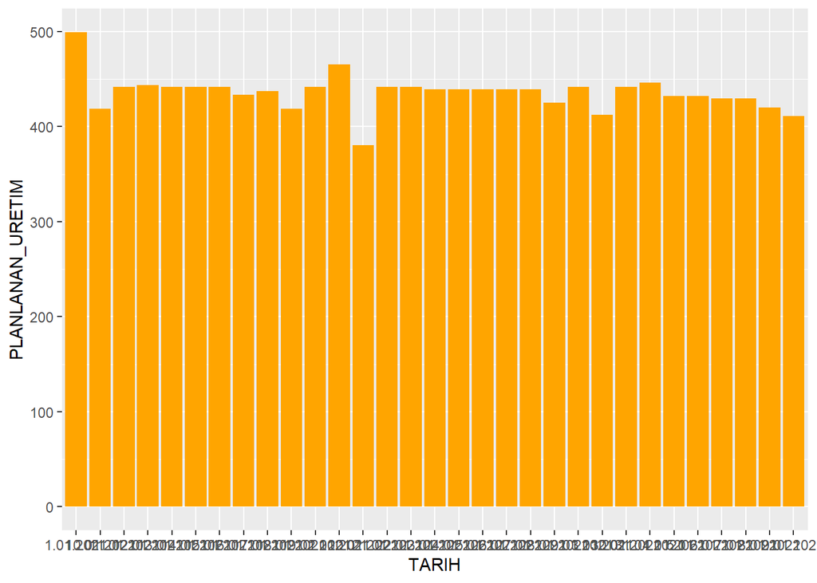

```r
ggplot2::ggplot(data = harmandali.enerji.uretimi, ggplot2::aes(x = TARIH, y = PLANLANAN_URETIM)) + ggplot2::geom_bar(stat="identity",fill="orange")
```

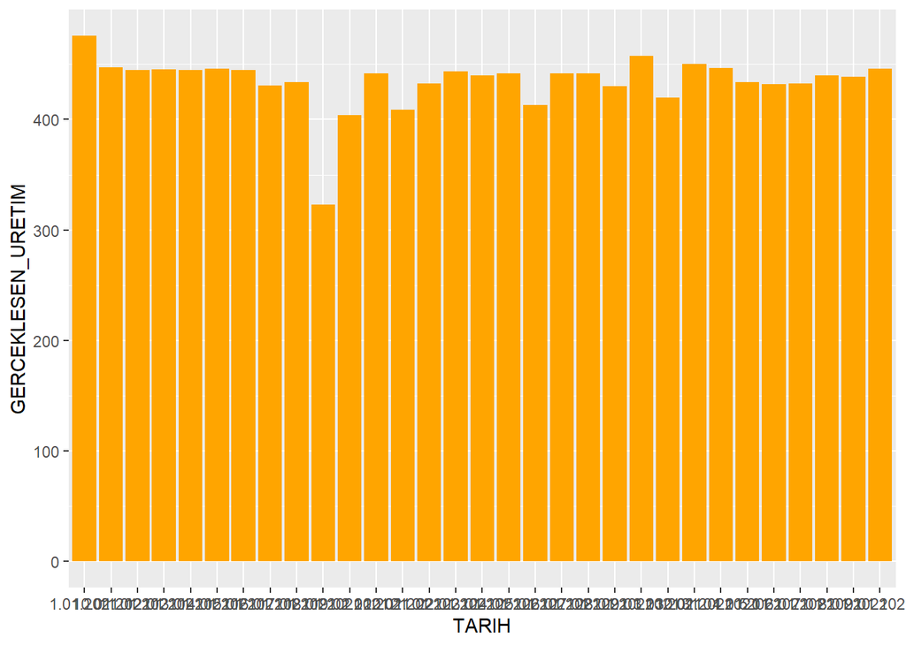

```r
ggplot2::ggplot(data = harmandali.enerji.uretimi, ggplot2::aes(x = TARIH, y = GERCEKLESEN_URETIM)) + ggplot2::geom_bar(stat="identity",fill="orange")
```

According to the above barchart, there is no definite increase/decrease order between the planned and realized electricity production. While the planned production is more than the actual production on some dates, it is less on some dates.

```r
diff(harmandali.enerji.uretimi$PLANLANAN_URETIM - harmandali.enerji.uretimi$GERCEKLESEN_URETIM)
```

```
##  [1]   0.22 -31.10   5.69   1.52  -2.79  -7.23  -8.46 -16.66   7.27  24.71
## [11]   1.71  -1.36  -1.39   1.09   5.68   0.73  92.66 -58.41 -65.54  37.41
## [21] -10.89   0.70  -1.30  28.32 -28.55  -0.14  -2.31 -11.37   7.67   8.58
```

# Confidence Interval

#### Dataset 1:

```r
mean(enerji.tuketimi.yolcubasina$IZMIR_METRO)
```

```
## [1] 1
```

```r
sd(enerji.tuketimi.yolcubasina$IZMIR_METRO)
```

```
## [1] 0.4340716
```

```r
norm.interval = function(data, variance, conf.level = 0.95) {
   z = qnorm((1 - conf.level)/2, lower.tail = FALSE)
   xbar = mean(data)
   sdx = sqrt(variance/length(data))
   c(xbar - z * sdx, xbar + z * sdx)
}

norm.interval(enerji.tuketimi.yolcubasina$IZMIR_METRO, variance=var(enerji.tuketimi.yolcubasina$IZMIR_METRO), conf.level = 0.95)
```

```
## [1] 0.7544054 1.2455946
```

```r
enerji.tuketimi.yolcubasina.CI <- t.test(enerji.tuketimi.yolcubasina$IZMIR_METRO)$conf.int
enerji.tuketimi.yolcubasina.CI
```

```
## [1] 0.724204 1.275796
## attr(,"conf.level")
## [1] 0.95
```

#### Dataset 2:

```r
mean(enerji.tuketimi.cer$IZMIR_METRO)
```

```
## [1] 2.136667
```

```r
sd(enerji.tuketimi.cer$IZMIR_METRO)
```

```
## [1] 0.3271734
```

```r
norm.interval = function(data, variance, conf.level = 0.95) {
   z = qnorm((1 - conf.level)/2, lower.tail = FALSE)
   xbar = mean(data)
   sdx = sqrt(variance/length(data))
   c(xbar - z * sdx, xbar + z * sdx)
}

norm.interval(enerji.tuketimi.cer$IZMIR_METRO, variance=var(enerji.tuketimi.cer$IZMIR_METRO), conf.level = 0.95)
```

```
## [1] 1.951554 2.321779
```

The output on the above is confidenece interval of the data. A point estimate for the true mean energy consumption in the per km is 2.136667 kwh, and we are 95% confident that the true mean is between 1.951554 kWh and 2.321779 kWh.

```r
enerji.tuketimi.yolcubasina.CI <- t.test(enerji.tuketimi.yolcubasina$IZMIR_METRO)$conf.int
enerji.tuketimi.yolcubasina.CI
```

[output not shown]

#### Dataset 3:

```r
mean(harmandali.enerji.uretimi$GERCEKLESEN_URETIM)
```

```
## [1] 434.5652
```

```r
sd(harmandali.enerji.uretimi$GERCEKLESEN_URETIM)
```

```
## [1] 24.89611
```

```r
norm.interval = function(data, variance, conf.level = 0.95) {
   z = qnorm((1 - conf.level)/2, lower.tail = FALSE)
   xbar = mean(data)
   sdx = sqrt(variance/length(data))
   c(xbar - z * sdx, xbar + z * sdx)
}

norm.interval(harmandali.enerji.uretimi$GERCEKLESEN_URETIM, variance=var(harmandali.enerji.uretimi$GERCEKLESEN_URETIM), conf.level = 0.95)
```

```
## [1] 425.8012 443.3291
```

The output on the above is confidenece interval of the data. A point estimate for the true mean electrical energy generation during the day is 434.5652 kwh, and we are 95% confident that the true mean is between 425.8012 kWh and 443.3291 kWh. The mean of the data is within the confidence interval we found.

```r
harmandali.enerji.uretimi.CI <- t.test(harmandali.enerji.uretimi$GERCEKLESEN_URETIM)$conf.int
harmandali.enerji.uretimi.CI
```

```
## [1] 425.4332 443.6971
## attr(,"conf.level")
## [1] 0.95
```

# Hypothesis Testing

### Dataset 1:

```r
enerji.tuketimi.yolcubasina.t.test<- t.test(enerji.tuketimi.yolcubasina$IZMIR_METRO, alternative = c("two.sided"), mu = 2, conf.level = 0.95)
enerji.tuketimi.yolcubasina.t.test
```

```
##
##  One Sample t-test
##
## data:  enerji.tuketimi.yolcubasina$IZMIR_METRO
## t = -7.9805, df = 11, p-value = 6.686e-06
## alternative hypothesis: true mean is not equal to 2
## 95 percent confidence interval:
##  0.724204 1.275796
## sample estimates:
## mean of x
##         1
```

Firstly, we need to find mean of enerji.tuketimi.yolcubasına$KARSIYAKA_TRAMVAYI

```r
mean(enerji.tuketimi.yolcubasina$KARSIYAKA_TRAMVAYI)
```

```
## [1] 1.665
```

```r
enerji.tuketimi.yolcubasina.t.test2<- t.test(enerji.tuketimi.yolcubasina$KARSIYAKA_TRAMVAYI, alternative = c("two.sided"), mu = 1, conf.level = 0.95)
enerji.tuketimi.yolcubasina.t.test2
```

```
##
##  One Sample t-test
##
## data:  enerji.tuketimi.yolcubasina$KARSIYAKA_TRAMVAYI
## t = 1.363, df = 11, p-value = 0.2001
## alternative hypothesis: true mean is not equal to 1
## 95 percent confidence interval:
##  0.5911159 2.7388841
## sample estimates:
## mean of x
##     1.665
```

```r
mean(enerji.tuketimi.yolcubasina$KONAK_TRAMVAYI)
```

```
## [1] 0.7016667
```

```r
enerji.tuketimi.yolcubasina.t.test3<- t.test(enerji.tuketimi.yolcubasina$KONAK_TRAMVAYI, alternative = c("two.sided"), mu = 1, conf.level = 0.95, var.equal = TRUE, paired = F)
enerji.tuketimi.yolcubasina.t.test3
```

```
##
##  One Sample t-test
##
## data:  enerji.tuketimi.yolcubasina$KONAK_TRAMVAYI
## t = -2.3539, df = 11, p-value = 0.03823
## alternative hypothesis: true mean is not equal to 1
## 95 percent confidence interval:
##  0.4227107 0.9806226
## sample estimates:
## mean of x
## 0.7016667
```

Result of this t test, we find a p-value as ~0.03.P value is less than alpha and we reject h0 hypothesis. Mean is not equal to 1.

### Dataset 2:

```r
mean(enerji.tuketimi.cer$IZMIR_METRO)
```

```
## [1] 2.136667
```

```r
enerji.tuketimi.cer.t.test4<- t.test(enerji.tuketimi.cer$IZMIR_METRO, alternative = c("two.sided"), mu = 1, conf.level = 0.95)
enerji.tuketimi.cer.t.test4
```

```
##
##  One Sample t-test
##
## data:  enerji.tuketimi.cer$IZMIR_METRO
## t = 12.035, df = 11, p-value = 1.129e-07
## alternative hypothesis: true mean is not equal to 1
## 95 percent confidence interval:
##  1.928791 2.344543
## sample estimates:
## mean of x
##  2.136667
```

```r
mean(enerji.tuketimi.cer$KARSIYAKA_TRAMVAYI)
```

```
## [1] 4.649167
```

```r
enerji.tuketimi.cer.t.test5<- t.test(enerji.tuketimi.cer$KARSIYAKA_TRAMVAYI, alternative = c("two.sided"), mu = 4, conf.level = 0.95)
enerji.tuketimi.cer.t.test5
```

```
##
##  One Sample t-test
##
## data:  enerji.tuketimi.cer$KARSIYAKA_TRAMVAYI
## t = 2.9759, df = 11, p-value = 0.01261
## alternative hypothesis: true mean is not equal to 4
## 95 percent confidence interval:
##  4.169041 5.129292
## sample estimates:
## mean of x
##  4.649167
```

```r
mean(enerji.tuketimi.cer$KONAK_TRAMVAYI)
```

```
## [1] 4.124167
```

```r
enerji.tuketimi.yolcubasina.t.test6<- t.test(enerji.tuketimi.yolcubasina$KONAK_TRAMVAYI, alternative = c("two.sided"), mu = 5, conf.level = 0.95, var.equal = TRUE, paired = F)
enerji.tuketimi.yolcubasina.t.test6
```

[output not shown]

Result of this t test, we find a p-value as ~0.001.P value is less than alpha and we reject h0 hypothesis. Mean is not equal to 5.

### Dataset 3:

```r
harmandali.enerji.uretimi.t.test<- t.test(harmandali.enerji.uretimi$PLANLANAN_URETIM, alternative = c("two.sided"), mu = 400, conf.level = 0.95)
harmandali.enerji.uretimi.t.test
```

```
##
##  One Sample t-test
##
## data:  harmandali.enerji.uretimi$PLANLANAN_URETIM
## t = 10.512, df = 30, p-value = 1.411e-11
## alternative hypothesis: true mean is not equal to 400
## 95 percent confidence interval:
##  428.7491 442.6128
## sample estimates:
## mean of x
##   435.681
```

```r
harmandali.enerji.uretimi.t.test2<- t.test(harmandali.enerji.uretimi$GERCEKLESEN_URETIM, alternative = c("two.sided"), mu = 400, conf.level = 0.95)
harmandali.enerji.uretimi.t.test2
```

```
##
##  One Sample t-test
##
## data:  harmandali.enerji.uretimi$GERCEKLESEN_URETIM
## t = 7.7301, df = 30, p-value = 1.266e-08
## alternative hypothesis: true mean is not equal to 400
## 95 percent confidence interval:
##  425.4332 443.6971
## sample estimates:
## mean of x
##  434.5652
```

Result of this t test, we find a p-value as ~0.0. P value is less than alpha and we reject h0 hypothesis.

### Bonus

The datas I have chosen are not suitable for the two-sample t-test. That’s why I’m going to use the dataset included with R.

```r
Iris <- read.csv("C:/Users/gulde/Downloads/Iris.csv")
head(Iris)
```

```
##   Id SepalLengthCm SepalWidthCm PetalLengthCm PetalWidthCm     Species
## 1  1           5.1          3.5           1.4          0.2 Iris-setosa
## 2  2           4.9          3.0           1.4          0.2 Iris-setosa
## 3  3           4.7          3.2           1.3          0.2 Iris-setosa
## 4  4           4.6          3.1           1.5          0.2 Iris-setosa
## 5  5           5.0          3.6           1.4          0.2 Iris-setosa
## 6  6           5.4          3.9           1.7          0.4 Iris-setosa
```

```r
iris.t.test <- t.test(SepalLengthCm~ Species, Iris, Species %in% c("Iris-versicolor", "Iris-virginica"), var.equal = T)
iris.t.test
```

```
##
##  Two Sample t-test
##
## data:  SepalLengthCm by Species
## t = -5.6292, df = 98, p-value = 1.725e-07
## alternative hypothesis: true difference in means between group Iris-versicolor and group Iris-virginica is not equal to 0
## 95 percent confidence interval:
##  -0.8818516 -0.4221484
## sample estimates:
## mean in group Iris-versicolor  mean in group Iris-virginica
##                         5.936                         6.588
```

The p-value is less than the significance level of so we can reject the null hypothesis.

#### Data Normality:

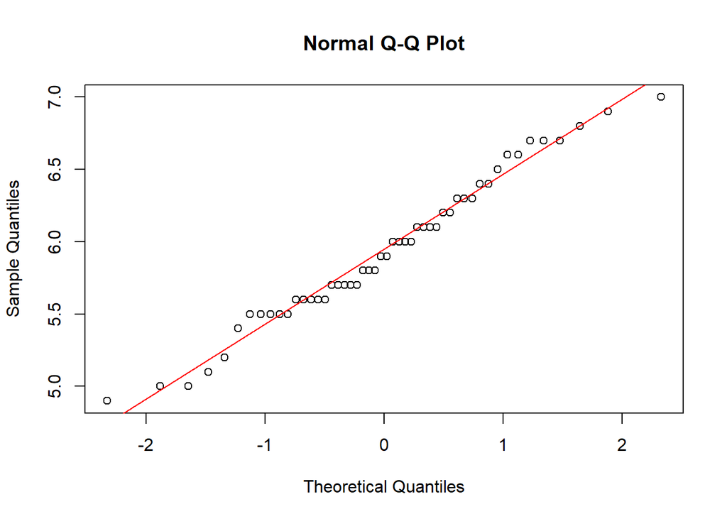

```r
with(Iris, qqnorm(SepalLengthCm[Species=="Iris-versicolor"]))
with(Iris, qqline(SepalLengthCm[Species=="Iris-versicolor"], col = "red"))
```

In this data the points to close to lying on a straight line. So we can say Iris data is normal.

# ANOVA / REGRESSİON

#### Dataset 1: H0: There is no difference between the means. (ANOVA)

```r
stations <- c(rep("KARSIYAKA_TRAMVAYI", 12),rep("IZMIR_METROSU", 12), rep("KONAK_TRAMVAYI", 12))


energy_consumption <- c(enerji.tuketimi.yolcubasina$KARSIYAKA_TRAMVAYI, enerji.tuketimi.yolcubasina$IZMIR_METRO, enerji.tuketimi.yolcubasina$KONAK_TRAMVAYI)

dataFrame <- data.frame(stations, energy_consumption)
dataFrame
```

```
##              stations energy_consumption
## 1  KARSIYAKA_TRAMVAYI               0.44
## 2  KARSIYAKA_TRAMVAYI               0.41
## 3  KARSIYAKA_TRAMVAYI               0.69
## 4  KARSIYAKA_TRAMVAYI               5.94
## 5  KARSIYAKA_TRAMVAYI               4.23
## 6  KARSIYAKA_TRAMVAYI               1.28
## 7  KARSIYAKA_TRAMVAYI               1.70
## 8  KARSIYAKA_TRAMVAYI               1.04
## 9  KARSIYAKA_TRAMVAYI               0.91
## 10 KARSIYAKA_TRAMVAYI               0.67
## 11 KARSIYAKA_TRAMVAYI               1.00
## 12 KARSIYAKA_TRAMVAYI               1.67
## 13      IZMIR_METROSU               0.52
## 14      IZMIR_METROSU               0.48
```

[output cut: 22 more lines]

```r
summary(dataFrame)
```

```
##    stations         energy_consumption
##  Length:36          Min.   :0.270
##  Class :character   1st Qu.:0.570
##  Mode  :character   Median :0.875
##                     Mean   :1.122
##                     3rd Qu.:1.220
##                     Max.   :5.940
```

```r
Anova <- aov(energy_consumption ~ stations, data = dataFrame)
summary(Anova)
```

```
##             Df Sum Sq Mean Sq F value Pr(>F)
## stations     2   5.84   2.918   2.704 0.0818 .
## Residuals   33  35.62   1.079
## ---
## Signif. codes:  0 '***' 0.001 '**' 0.01 '*' 0.05 '.' 0.1 ' ' 1
```

### Dataset 2: H0: There is no difference between the means. (ANOVA)

```r
stations2 <- c(rep("KARSIYAKA_TRAMVAYI", 12),rep("IZMIR_METROSU", 12), rep("KONAK_TRAMVAYI", 12))


energy_consumption2 <- c(enerji.tuketimi.cer$KARSIYAKA_TRAMVAYI, enerji.tuketimi.cer$IZMIR_METRO, enerji.tuketimi.cer$KONAK_TRAMVAYI)

dataFrame2 <- data.frame(stations, energy_consumption)
dataFrame2
```

```
##              stations energy_consumption
## 1  KARSIYAKA_TRAMVAYI               0.44
## 2  KARSIYAKA_TRAMVAYI               0.41
## 3  KARSIYAKA_TRAMVAYI               0.69
## 4  KARSIYAKA_TRAMVAYI               5.94
## 5  KARSIYAKA_TRAMVAYI               4.23
## 6  KARSIYAKA_TRAMVAYI               1.28
## 7  KARSIYAKA_TRAMVAYI               1.70
## 8  KARSIYAKA_TRAMVAYI               1.04
## 9  KARSIYAKA_TRAMVAYI               0.91
## 10 KARSIYAKA_TRAMVAYI               0.67
## 11 KARSIYAKA_TRAMVAYI               1.00
## 12 KARSIYAKA_TRAMVAYI               1.67
## 13      IZMIR_METROSU               0.52
## 14      IZMIR_METROSU               0.48
```

[output cut: 22 more lines]

```r
summary(dataFrame2)
```

```
##    stations         energy_consumption
##  Length:36          Min.   :0.270
##  Class :character   1st Qu.:0.570
##  Mode  :character   Median :0.875
##                     Mean   :1.122
##                     3rd Qu.:1.220
##                     Max.   :5.940
```

```r
Anova2 <- aov(energy_consumption2 ~ stations2, data = dataFrame2)
summary(Anova2)
```

```
##             Df Sum Sq Mean Sq F value   Pr(>F)
## stations2    2  42.15  21.077   52.87 5.12e-11 ***
## Residuals   33  13.16   0.399
## ---
## Signif. codes:  0 '***' 0.001 '**' 0.01 '*' 0.05 '.' 0.1 ' ' 1
```

[output not shown]

[output not shown]

```r
test_set
```

```
##         TARIH PLANLANAN_URETIM GERCEKLESEN_URETIM
## 2   2.01.2021           465.60             441.84
## 4   4.01.2021           432.00             433.65
## 5   5.01.2021           432.00             432.13
## 8   8.01.2021           420.30             438.91
## 11 11.01.2021           441.60             444.89
## 16 16.01.2021           433.20             430.76
## 20 20.01.2021           380.40             408.52
## 21 21.01.2021           441.60             432.31
## 24 24.01.2021           439.20             441.40
## 26 26.01.2021           439.20             441.63
## 31 31.01.2021           446.31             446.31
```

In the above table, we determined a random variable for sampling and split the datas as True or False.

```r
reg <- lm(formula = GERCEKLESEN_URETIM ~ PLANLANAN_URETIM, data= training_set)
summary(reg)
```

```
##
## Call:
## lm(formula = GERCEKLESEN_URETIM ~ PLANLANAN_URETIM, data = training_set)
##
## Residuals:
##     Min      1Q  Median      3Q     Max
## -97.456   2.889   5.761   9.019  31.705
##
## Coefficients:
##                  Estimate Std. Error t value Pr(>|t|)
## (Intercept)      104.4257   153.5020   0.680   0.5050
## PLANLANAN_URETIM   0.7545     0.3512   2.149   0.0455 *
## ---
## Signif. codes:  0 '***' 0.001 '**' 0.01 '*' 0.05 '.' 0.1 ' ' 1
##
## Residual standard error: 27.79 on 18 degrees of freedom
## Multiple R-squared:  0.2041, Adjusted R-squared:  0.1599
## F-statistic: 4.616 on 1 and 18 DF,  p-value: 0.04553
```

It is aimed to establish a model that predicts the actual production according to the planned production above. We use the regression model for this, because there are dependent and independent variable. As seen in the table above, the p value(0.04) is less than .05. This means that the model is normal and we can use this model.

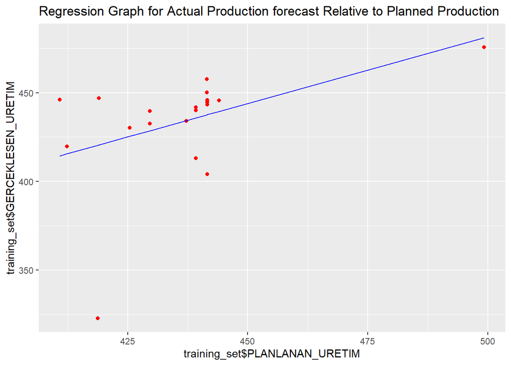

```r
ggplot2::ggplot()+
 ggplot2::geom_point(ggplot2::aes(x = training_set$PLANLANAN_URETIM, y = training_set$GERCEKLESEN_URETIM), color='red') + ggplot2::geom_line(ggplot2::aes(x = training_set$PLANLANAN_URETIM, y = predict(reg, newdata = training_set)),
 color = 'blue')+
 ggplot2::ggtitle('Regression Graph for Actual Production forecast Relative to Planned Production  ')
```

When we look at the graph, although we cannot say that all points extend to the length of the line, we can say that enough points extend to the line.

# References

-González-Rodríguez, Gil, Ana Colubi, and María Ángeles Gil. “Fuzzy data treated as functional data: A one-way ANOVA test approach.” Computational Statistics & Data Analysis 56.4 (2012): 943-955. -Dr.Zeynep Filiz EREN DOGU, CENG 3516 STATISTICAL COMPUTING “Lecture 6 - Confidence Intervals and Hypothesis testing in R.” Mar 10, 2021